# Company Bankruptcy Prediction

#### Angela Wei, Aditya Desai, Andrew Theiss, and Samuel Gadkar

#### December 14th, 2025

## Introduction

This project analyzes a company bankruptcy dataset consisting of financial statement information and other firm-level financial metrics, with the goal of understanding how measurable financial factors contribute to predicting bankruptcy. The training dataset contains 4,773 observations and 97 variables, of which 96 are numeric financial predictors. The response variable, Bankrupt, is binary, indicating whether a firm declared bankruptcy (1) or not (0).

Because the predictors are entirely numeric and represent standardized or normalized financial ratios, careful exploratory analysis is required to assess data quality, detect extreme or implausible values, and understand the structural relationships among variables. In addition, financial ratios tend to be highly correlated, and the response exhibits severe class imbalance, with bankruptcy cases representing only a small portion of the dataset. These characteristics introduce modeling challenges, including multicollinearity, noisy predictors, and uneven class representation.

Given these complexities, our analysis begins by exploring the distribution of predictors, identifying anomalous values, examining relationships between variables and the response, and grouping financial ratios into meaningful categories. This foundation informs the selection, tuning, and evaluation of predictive models for effectively and interpretably classifying bankruptcy risk.

## Exploratory Data Analysis

We began with an exploratory data analysis to understand the dataset’s structure, quality, and key characteristics. This included examining variable types, identifying potential data quality issues such as extreme or missing values, assessing relationships between predictors and the response, and identifying early signals of which financial variables may be associated with bankruptcy. These steps provide the necessary context for model selection and help ensure that downstream modeling decisions are grounded in the underlying data patterns.

### Data Problems

A review of summary statistics revealed significant data quality issues within the dataset. Many predictors contained extreme and implausible values, especially variables representing financial ratios that should normally fall within a constrained economic range. Several predictors included values ranging from 10 to $10^{10}$, which are not realistic for standardized financial metrics and are likely due to data entry errors, scaling inconsistencies, or firms with extremely unusual financial structures.

These extreme values raise concerns because:

- They can distort model coefficients, especially in linear or distance-based models such as logistic regression or KNN.
- They may inflate variances, reducing model stability.
- They can affect correlation estimates, misleading variable selection and interpretation.

A list of predictors with the most extreme values is shown below.

##### Variables With Extreme Values

|  | x |
| --- | --- |
| Cash.Turnover.Rate | 1.00e+10 |
| Operating.Expense.Rate | 9.99e+09 |
| Total.Asset.Growth.Rate | 9.99e+09 |
| Inventory.Turnover.Rate..times. | 9.99e+09 |
| Fixed.Assets.Turnover.Frequency | 9.99e+09 |
| Current.Asset.Turnover.Rate | 9.99e+09 |
| Quick.Asset.Turnover.Rate | 9.99e+09 |
| Research.and.development.expense.rate | 9.98e+09 |
| Total.debt.Total.net.worth | 9.94e+09 |
| Inventory.Current.Liability | 9.91e+09 |
| Total.assets.to.GNP.price | 9.82e+09 |
| Accounts.Receivable.Turnover | 9.74e+09 |
| Average.Collection.Days | 9.73e+09 |
| Allocation.rate.per.person | 9.57e+09 |
| Long.term.Liability.to.Current.Assets | 9.54e+09 |
| Cash.Current.Liability | 9.41e+09 |
| Net.Value.Growth.Rate | 9.33e+09 |
| Quick.Ratio | 9.23e+09 |
| Quick.Assets.Current.Liability | 8.82e+09 |
| Revenue.per.person | 8.81e+09 |
| Fixed.Assets.to.Assets | 8.32e+09 |
| Revenue.Per.Share..Yuan… | 3.02e+09 |
| Current.Ratio | 2.75e+09 |
| Interest.bearing.debt.interest.rate | 9.90e+08 |

### Variable Types

The dataset contains 96 numeric predictors, each representing a different financial ratio or performance indicator used to explain the binary response variable, Bankruptcy. Although the predictors span many specific accounting measures, they can be broadly organized into five major financial categories, each capturing a different dimension of a firm’s financial health. Grouping variables this way helps clarify how different types of financial risk relate to bankruptcy likelihood.

##### Profitability Predictors

| Predictor |
| --- |
| ROA.A..before.interest.and…after.tax |
| ROA.B..before.interest.and.depreciation.after.tax |
| ROA.C..before.interest.and.depreciation.before.interest |
| Net.Income.to.Total.Assets |

Profitability ratios measure how effectively a company generates income relative to its assets or equity. These variables capture operational efficiency, return on investments, and overall financial performance.

##### Liquidity Predictors

| Predictor |
| --- |
| Current.Ratio |
| Working.Capital.to.Total.Assets |

Liquidity measures a company’s ability to convert assets into cash quickly to meet short-term financial obligations. Low liquidity often signals a higher risk of financial distress or default.

##### Leverage Predictors

| Predictor |
| --- |
| Debt.ratio.. |
| Total.debt.Total.net.worth |

Leverage ratios describe a firm’s capital structure—specifically, how much of its financing comes from debt rather than equity. Highly leveraged firms may face increased bankruptcy risk due to heavier repayment burdens.

##### Turnover Predictors

| Predictor |
| --- |
| Cash.Turnover.Rate |
| Inventory.Turnover.Rate..times. |

Turnover ratios capture how efficiently a company uses its assets to generate sales or revenue. Higher turnover generally reflects effective asset utilization, while low turnover may indicate inefficiency or operational challenges.

##### Cash Flow Predictors

| Predictor |
| --- |
| Cash.Flow.to.Total.Assets |
| Cash.Current.Liability |

Cash flow measures reflect the generation and movement of cash within a company. Since insolvency ultimately occurs when firms cannot meet cash obligations, these variables often play an important role in bankruptcy prediction.

### Missing Data

##### Missing Data?

| x |
| --- |
| FALSE |

A formal check of the dataset confirms that no missing values are present in any of the 96 predictors or in the response variable. This is a notable advantage, as it means no imputation, deletion, or data augmentation procedures are required. With complete data across all variables, we can proceed directly to modeling without concerns about bias or information loss from missing values.

### Collinearity Issues

##### Number of Correlated Pairs > 0.8

| x |
| --- |
| 43 |

##### Top 10 Highest Correlated Predictors

| Var1 | Var2 | Freq | abs_corr |
| --- | --- | --- | --- |
| Current.Liability.to.Liability | Current.Liabilities.Liability | 1.0000000 | 1.0000000 |
| Current.Liabilities.Liability | Current.Liability.to.Liability | 1.0000000 | 1.0000000 |
| Current.Liability.to.Equity | Current.Liabilities.Equity | 1.0000000 | 1.0000000 |
| Current.Liabilities.Equity | Current.Liability.to.Equity | 1.0000000 | 1.0000000 |
| Net.worth.Assets | Debt.ratio.. | -1.0000000 | 1.0000000 |
| Debt.ratio.. | Net.worth.Assets | -1.0000000 | 1.0000000 |
| Gross.Profit.to.Sales | Operating.Gross.Margin | 1.0000000 | 1.0000000 |
| Operating.Gross.Margin | Gross.Profit.to.Sales | 1.0000000 | 1.0000000 |
| Net.Value.Per.Share..C. | Net.Value.Per.Share..A. | 0.9998889 | 0.9998889 |
| Net.Value.Per.Share..A. | Net.Value.Per.Share..C. | 0.9998889 | 0.9998889 |

There is significant collinearity among the predictors, which is expected given the financial nature of the dataset. Many financial ratios are built from the same underlying accounting quantities, so strong relationships between predictors are unavoidable. After removing variables with zero variance, a pairwise correlation analysis revealed that 43 predictor pairs exhibited absolute correlations exceeding 0.8, confirming substantial redundancy in the feature set.

Several examples illustrate why these correlations occur. Measures such as Net Worth to Assets and Debt Ratio are inversely related by definition, and Gross Profit to Sales versus Operating Gross Margin capture nearly identical aspects of profitability. Similar patterns appear across liquidity, leverage, turnover, and cash-flow metrics, where different ratios reflect the same underlying financial behaviors. This overlap helps explain why so many predictors move together.

Such high collinearity presents challenges for traditional modeling, especially linear and logistic regression, where correlated predictors can lead to unstable or inflated coefficient estimates. Because of this, our analysis relied on regularized methods, most notably Ridge Regression, which shrinks correlated predictors together and reduces their variance without removing them. This allowed the final model to remain stable, interpretable, and robust despite the dataset’s high redundancy.

### Potential Important Predictors

##### Variables With |Correlation| > 0.20 With Bankruptcy

|  | Variable | Correlation |
| --- | --- | --- |
| Bankrupt. | Bankrupt. | 1.0000000 |
| Net.Income.to.Total.Assets | Net.Income.to.Total.Assets | -0.2657764 |
| ROA.A..before.interest.and…after.tax | ROA.A..before.interest.and…after.tax | -0.2445629 |
| Debt.ratio.. | Debt.ratio.. | 0.2390449 |
| Net.worth.Assets | Net.worth.Assets | -0.2390449 |
| ROA.B..before.interest.and.depreciation.after.tax | ROA.B..before.interest.and.depreciation.after.tax | -0.2345945 |
| ROA.C..before.interest.and.depreciation.before.interest | ROA.C..before.interest.and.depreciation.before.interest | -0.2260162 |

##### Top 15 Variables With the Lowest t-Test p-Values

|  | Variable | P_Value |
| --- | --- | --- |
| Net.Value.Per.Share..A. | Net.Value.Per.Share..A. | 0 |
| Net.Value.Per.Share..B. | Net.Value.Per.Share..B. | 0 |
| Net.Value.Per.Share..C. | Net.Value.Per.Share..C. | 0 |
| Net.worth.Assets | Net.worth.Assets | 0 |
| Debt.ratio.. | Debt.ratio.. | 0 |
| Operating.profit.Paid.in.capital | Operating.profit.Paid.in.capital | 0 |
| Cash.Total.Assets | Cash.Total.Assets | 0 |
| Operating.Profit.Per.Share..Yuan… | Operating.Profit.Per.Share..Yuan… | 0 |
| Per.Share.Net.profit.before.tax..Yuan… | Per.Share.Net.profit.before.tax..Yuan… | 0 |
| Persistent.EPS.in.the.Last.Four.Seasons | Persistent.EPS.in.the.Last.Four.Seasons | 0 |
| Net.profit.before.tax.Paid.in.capital | Net.profit.before.tax.Paid.in.capital | 0 |
| ROA.C..before.interest.and.depreciation.before.interest | ROA.C..before.interest.and.depreciation.before.interest | 0 |
| Working.Capital.to.Total.Assets | Working.Capital.to.Total.Assets | 0 |
| ROA.B..before.interest.and.depreciation.after.tax | ROA.B..before.interest.and.depreciation.after.tax | 0 |
| ROA.A..before.interest.and…after.tax | ROA.A..before.interest.and…after.tax | 0 |

To identify early signs of which variables may be useful for predicting bankruptcy, we examined both pairwise correlations with the response and results from two-sample t-tests comparing firms that did and did not declare bankruptcy. Several predictors consistently appeared in both analyses, indicating stronger relationships with bankruptcy outcomes.

From a profitability perspective, variables such as Net Income to Total Assets and the various ROA measures (A/B/C) showed a strong association with bankruptcy. These ratios capture whether firms are generating sufficient earnings relative to their assets—something that typically deteriorates well before bankruptcy. Since the ROA variants are nearly perfectly correlated with each other, they represent the same underlying signal, and only one would need to be included in downstream models.

Among financial leverage measures, the Debt Ratio emerged as one of the most important predictors. This aligns with economic intuition: firms with higher leverage face greater financial strain and are more vulnerable during downturns or periods of poor cash flow.

Finally, liquidity indicators such as Working Capital to Total Assets and Cash Total Assets also appeared significant. Both metrics reflect a firm’s ability to cover short-term obligations. Lower liquidity is often an early warning sign of distress and can precede bankruptcy filings.

Together, these variables—spanning profitability, leverage, and liquidity- represent intuitive and meaningful financial dimensions that may serve as strong predictors of bankruptcy risk. They provide useful guidance for model building and highlight which financial signals deteriorate earliest in failing firms.

### Key Figures and Numerical Summaries

##### Summary of Bankruptcy Response

| Category | Proportion |
| --- | --- |
| Min. | 0.0000000 |
| 1st Qu. | 0.0000000 |
| Median | 0.0000000 |
| Mean | 0.0293317 |
| 3rd Qu. | 0.0000000 |
| Max. | 1.0000000 |

##### Bankruptcy Response Classification Split

| Category | Proportion |
| --- | --- |
| 0 | 0.9706683 |
| 1 | 0.0293317 |

The response variable Bankruptcy is a binary indicator: 1 indicates a bankrupt firm and 0 indicates a non-bankrupt firm. The summary statistics show that bankruptcy cases make up only 2.93% of the training dataset, while 97.07% of firms are healthy. The mean response (0.0293) reflects the extremely low event rate, confirming that bankruptcy is a rare outcome.

This severe class imbalance has important implications for modeling. Standard classifiers may default to predicting the majority class, so careful consideration of evaluation metrics—such as sensitivity, specificity, and AUC- is necessary to ensure meaningful performance. The imbalance also highlights the need for models that can effectively detect minority-class events, since identifying bankrupt firms is ultimately the key objective of this prediction task.

### Potential Models

The exploratory analysis highlighted several key characteristics of the dataset that directly inform model choice. The most critical issue is the severe class imbalance, with only about 3% of firms classified as bankrupt. Additionally, the predictors show meaningful separation across financial performance categories—profitability, leverage, liquidity, and earnings stability all differ notably between bankrupt and non-bankrupt firms. However, the dataset also contains extreme outliers with implausibly large magnitudes and high redundancy, as many predictors are nearly identical or highly correlated.

Given these challenges, models that reduce dimensionality and handle multicollinearity, such as regularized logistic regression (Ridge or Lasso) or tree-based methods, are more appropriate than unregularized linear models. Class imbalance must be explicitly addressed, and evaluation metrics should emphasize sensitivity and recall rather than accuracy alone, since failing to detect a bankrupt firm is far more costly than a false positive. These considerations strongly motivated the exploration of regularized models and ultimately informed the selection of our final predictive model.

## Model Analysis

### Investigated Models, Description, and Assumptions

Prior to our exploratory data analysis, we planned to train and test our data using three methods: KNN, PLS, and Classification/Regression Trees. However, after analyzing the structure of our data and evaluating initial model performance, several issues became clear:

- Extreme Class Imbalance: Bankruptcy cases make up only a small fraction of the dataset, causing these methods ot default to predicting the majority class.
- High-Dimensional Numeric Ratios: The dataset contains many correlated financial ratios, which introduces noise and instability, especially harmful for KNN and PLS.
- Nonlinear Relationships: The relationship between financial predictors and bankruptcy risk is highly nonlinear, limiting the effectiveness of simple tree models and linear projections.
- Overlapping Distributions: Bankrupt and non-bankrupt have very similar predictor values, making it difficult for distance-based or linear-separation methods to distinguish between classes.

Given these challenges, we shifted our focus to models that are more robust to imbalance, multicollinearity, and complex structure. Specifically, we explored Ridge Regression, LASSO, Bagging, and Random Forest, which provided significantly stronger performance and more stable predictions. We examine these models and their results in the following sections.

#### Ridge Regression

The first model we explored was Ridge Regression, which is well-suited for datasets with highly correlated predictors, many numerical variables, substantial noise, and class imbalance—all characteristics that appeared in our exploratory analysis. Because Ridge is designed to stabilize coefficient estimates in these settings, it was a strong candidate for our bankruptcy prediction task.

Definition and Formula: Ridge Regression estimates the coefficients by minimizing the usual sum of squared errors subject ot an L2 penalty that shrinks the coefficients towards zero:

$\hat\beta_{Ridge} = argmin_{\beta} \sum_{i=1}^n (y_i - \beta_0 - \sum_{j=1}^p \beta_jx_{ij}) ^ 2$ subject to $\sum_{j=1}^p \beta_j^2 \le s$

Here:

- $\lambda \ge 0$ is the tuning parameter controlling shrinkage
- Larger $\lambda$ forces coefficients toward 0 (reducing variance)
- Ridge is useful when predictors are highlight correlated, numerous, or the model risks overfitting

Assumptions: Ridge Regression inherits the assumptions of logistic regression, but relaxes some of them through its L2 penalty

1. Linearity of log-odds: The model assumes a linear relationship between predictors and the log-odds of bankruptcy
   1. Our check: Probability plots show some nonlinear patterns, meaning this assumption is not fully met
   2. Why acceptable: Ridge is robust to mild misspecification because shrinkage stabilizes coefficients
2. No perfect multicollinearity: Predictors should ot be perfectly correlated
   1. Our check: Many financial ratios are highly correlated
   2. Why acceptable: This is exactly what Ridge is designed for; L2 regularization handles multicollinearity by shrinking correlated coefficients together
3. Independent observations: Each row must represent an independent company
   1. Our check: Firms appear only once, so this assumption is satisfied
4. Reasonable class balance: Logistic regression is sensitive to imbalance
   1. Our check: The data is extremely imbalanced
   2. How addressed: We used class weights in the Ridge model to compensate

Assumption Summary: Although the dataset violates the linearity and balance assumptions, Ridge Regression remains appropriate because the L2 penalty directly addresses multicollinearity, reduces variance, and performs well in noisy, high-dimensional settings, as supported by its strong AUC and sensitivity in our results.

After training the model and evaluating it on the test set, we obtained the following confusion matrix:

Ridge Regression Confusion Matrix

|  | Actual Not Bankrupt | Actual Bankrupt |
| --- | --- | --- |
| Predicted Not Bankrupt | 1687 | 11 |
| Predicted Bankrupt | 279 | 69 |

From this output, we calculated several performance metrics:

- Accuracy = 0.8583 - The model correctly classified about 86% of all firms in the test set.
- Sensitivity = 0.8625 - The model correctly identified approximately 86% of actual bankrupt companies, which is important given our goal of catching high-risk firms.
- Specificity = 0.8581 - About 86% of non-bankrupt firms were correctly labeled, indicating strong performance on the majority class.
- AUC = 0.9318 - This value shows that Ridge Regression is excellent at separating bankrupt vs. non-bankrupt firms across all classification thresholds, reflecting strong overall discriminative ability.

Overall, Ridge Regression performs well on this dataset and effectively balances sensitivity and specificity, making it a strong foundation for further analysis.

#### LASSO

The next model we evaluated was LASSO Regression, which is particularly useful for datasets with many predictors and potential redundancy. Unlike Ridge, which shrinks all coefficients, LASSO can set some coefficients to zero, effectively performing feature selection. Given the high dimensionality of the financial ratios in our dataset, LASSO was a strong candidate because it helps identify the most important predictors while reducing noise.

Definition and Formula: LASSO (Least Absolute Shrinkage and Selection Operator) estimates the coefficients by minimizing the sum of squared errors subject to an L1 penalty, which both shrinks coefficients and can set some exactly to zero (performing variable selection)

$\hat\beta_{LASSO} = argmin_{\beta} \sum_{i=1}^n (y_i - \beta_0 - \sum_{j=1}^p \beta_jx_{ij}) ^ 2$ subject to $\sum_{j=1}^p |\beta_j| \le s$

Here:

- $\lambda \ge 0$ controls the amount of shrinkage
- The L1 penalty forces some coefficients exactly to zero
- LASSO is especially useful when feature selection is desired or when many predictors are irrelevant

Assumptions: LASSO relies on the same core assumptions as logistic regression, but its L1 penalty adds sparsity and variable selection.

1. Linearity of the log-odds: The model assumes a linear relationship between predictors and the log-odds of bankruptcy
   1. Our check: Probability plots showed some nonlinear patterns, so this assumption is not perfectly met
   2. Why acceptable: LASSO’s regularization helps reduce overfitting even when the relationship is not perfectly linear
2. No perfect multicollinearity: Predictors should not be perfectly correlated
   1. Our check: Financial ratios are strongly correlated
   2. Issue: LASSO tends to pick one variable from a correlated group and discard the rest, which can create instability.
   3. Why acceptable: This behavior is actually useful for variable selection, and the model still performed well in testing.
3. Independent observations: Each observation should be independent
   1. Our check: Each company appears once, so this assumption is satisfied
4. Class balance: Logistic-based models can struggle with extreme imbalance
   1. Our check: The dataset is highly imbalanced
   2. How addressed: Class weights were used to reduce bias toward the majority class

Assumption Summary: LASSO does not perfectly satisfy linearity or balance assumptions, and its variable selection can be unstable under multicollinearity. However, it still performed strongly and produced a sparse, interpretable model, making it a useful complementary approach, even if not the final chosen model.

After fitting the LASSO model on the training set and evaluating it on the test set, we obtained the following confusion matrix:

LASSO Confusion Matrix

|  | Actual Not Bankrupt | Actual Bankrupt |
| --- | --- | --- |
| Predicted Not Bankrupt | 1694 | 12 |
| Predicted Bankrupt | 272 | 68 |

From this, we computed the key performance metrics:

- Accuracy = 0.8612 - The model correctly classified about 86% of the companies in the test set.
- Sensitivity = 0.8500 - LASSO correctly identified about 85% of the actual bankrupt companies.
- Specificity = 0.8616 - About 86% of the non-bankrupt companies were correctly classified.
- AUC = 0.9301 - This indicates excellent class separation, nearly as strong as Ridge, demonstrating that LASSO is also highly effective at distinguishing between bankrupt and non-bankrupt firms across all thresholds.

Overall, LASSO performed very similarly to Ridge, with strong accuracy and discrimination ability. Its slightly lower sensitivity compared to Ridge suggests it identifies slightly fewer bankrupt firms, but its interpretability advantage (automatic variable selection) makes it especially useful for understanding which financial ratios matter most.

#### Bagging

Bagging is an ensemble method that reduces variance by training many decision trees on bootstrapped samples of the data and averaging their predictions. Because individual trees are highly sensitive to noise and instability, bagging helps stabilise predictions, making it a strong candidate for noisy, high-dimensional, and imbalanced datasets like ours.

Definition and Formula: Bagging is an ensemble learning method that reduces variance by training multiple models on different bootstrap samples of the data and averaging their predictions:

$\hat f_{bag}(x) = \frac{1}{B}\sum_{b=1}^B \hat f_b(x)$

Where:

- B is the number of bootstrap samples
- Each $\hat f_b(x)$ is the model trained on the b-th bootstrap sample
- The final prediction is the average of all models for regression or a majority vote for classification

Assumptions: Bagging relies on far fewer assumptions than statistical models like logistic regression. Since it uses machine-learning decision trees trained on bootstrapped samples, it is flexible, nonparametric, and robust to complex nonlinear relationships.

1. No linearity assumption: Decision trees do not require linear relationships between predictors and the outcome
   1. Our check: Our exploratory plots showed nonlinear trends in several financial ratios, making Bagging appropriate
2. Handles multicollinearity: Tree-based models are not affected by strongly correlated predictors
   1. Our check: Many ratios in our dataset were highly correlated, and Bagging naturally manages this without instability
3. Handles outliers and skewed variables: Decision trees partition data based on thresholds, so extreme values do not distort the model
   1. Our check: Several financial ratios were heavily skewed; Bagging remains reliable under these conditions
4. No distributional assumptions: Bagging does not assume normality or equal variances
   1. Our check: These assumptions were violated in the data, but Bagging does not require them
5. Requires reasonably independent observations: Observations should not be duplicated or repeated entities
   1. Our check: Each fire is observed once, so this assumption is met

Assumption Summary: Although Bagging does not directly correct the extreme class imbalance, we addressed this using balanced sampling

When we evaluated the Bagging model on the test set, the confusion matrix was:

Bagging Confusion Matrix

|  | Actual Not Bankrupt | Actual Bankrupt |
| --- | --- | --- |
| Predicted Not Bankrupt | 1755 | 19 |
| Predicted Bankrupt | 211 | 61 |

From this output, we obtained the following metrics:

- Accuracy = 0.8876 - The model correctly classified about 89% of all companies in the test set.
- Sensitivity = 0.7625 - Bagging identified roughly 76% of bankrupt companies, which is strong given the severe class imbalance.
- Specificity = 0.8927 - Nearly 89% of non-bankrupt firms were correctly labelled.
- AUC = 0.9281 - This high AUC indicates that Bagging separates bankrupt vs. non-bankrupt companies well across all probability thresholds.

Overall, Bagging performed very well, achieving a strong balance between sensitivity and specificity, making it one of our top-performing models.

#### Random Forest

Random Forest builds on the idea of Bagging by adding an additional layer of randomness. Each tree in the ensemble is trained on a bootstrapped sample and only a random subset of predictors at each split. This helps decorrelate the trees, reduces overfitting, and often improves performance, especially in datasets with many correlated financial ratios, like ours.

Definition and Formula: Random Forest is an ensemble learning method that builds multiple decision trees using both bootstrap samples of the data and random subsets of predictors at each split, reducing variance and limiting overfitting:

$\hat f_{RF}(x) = \frac{1}{B}\sum_{b=1}^B T_b(x)$

Where:

- B is the number of trees
- $T_b(x)$ is the prediction from the b-th decision tree
- Each tree is trained on a bootstrap sample and, at each split, chooses from a random subset of predictors rather than all predictors

Assumptions: Random Forest is a nonparametric ensemble method with far fewer assumptions than linear models, making it well-suited for noisy, high-dimensional financial data.

1. Independence of observations: Each row should represent an independent data point
   1. Our Check: Each firm appears once in the dataset, so this assumption is satisfied
2. Sufficient variability and sample size: Random Forest requires enough data for bootstrapping to create diverse trees
   1. Our Check: With thousands of firms and many predictors, the dataset provides ample variation
   2. Why Acceptable: The model produced stable out-of-bag error estimates, indicating enough data for reliable tree construction
3. No assumptions of linearity or normality: Random Forest does not require linear relationships, normally distributed predictors, or homoscedasticity
   1. Our Check: Financial ratios showed strong nonlinear relationships and skewed distributions
   2. Why Acceptable: These patterns are expected in bankruptcy data, and Random Forest naturally captures nonlinear interactions
4. Handles multicollinearity automatically: Tree-based models are not affected by correlated predictors
   1. Our Check: Many features were heavily correlated
   2. Why Acceptable: Random feature selection prevents trees from repeatedly splitting on the same correlated variables, reducing overfitting

Assumption Summary: Random Forest satisfies its core assumptions and is well-matched to this dataset’s structure: nonlinear relationships, correlated financial ratios, and high dimensionality.

After training the Random Forest model on our dataset, the confusion matrix was:

Random Forest Confusion Matrix

|  | Actual Not Bankrupt | Actual Bankrupt |
| --- | --- | --- |
| Predicted Not Bankrupt | 1759 | 19 |
| Predicted Bankrupt | 207 | 61 |

#### Model Comparison

After running all four models, we compared their performance using the key metrics discussed earlier:

Model Performance Comparison

| Model | Accuracy | Sensitivity | Specificity | Balanced_Accuracy | AUC |
| --- | --- | --- | --- | --- | --- |
| Ridge | 0.8583 | 0.8625 | 0.8581 | 0.8603 | 0.9318 |
| LASSO | 0.8612 | 0.8500 | 0.8616 | 0.8558 | 0.9301 |
| Bagging | 0.8876 | 0.7625 | 0.8927 | 0.8276 | 0.9281 |
| RandomForest | 0.8895 | 0.7625 | 0.8947 | 0.8286 | 0.9305 |

Across the models, performance was similar, but each model showed strengths in different areas. Random Forest achieved the highest overall accuracy and specificity, indicating it excelled at correctly identifying non-bankrupt companies. Bagging performed similarly well in these categories, followed by LASSO and Ridge. Since Random Forest performed well on both accuracy and specificity, it also achieved one of the second-highest AUC values among the models.

However, when focusing on sensitivity (the model’s ability to correctly identify companies that actually went bankrupt), Ridge Regression performed the best. Ridge correctly flagged the largest proportion of bankrupt firms, making it the strongest model for detecting the rare but critical positive class. Ridge also achieved the highest overall AUC, indicating that it best separates bankrupt from non-bankrupt companies across all probability thresholds.

Therefore, the final model selected was Ridge Regression.

#### Challenges Faced

We also explored several alternative models, each of which revealed specific limitations under these conditions. KNN struggled heavily with the curse of dimensionality and the imbalance problem, leading to poor minority-class detection. PLS regression handled multicollinearity but could not capture important nonlinear relationships in the data. Classification trees were highly unstable and prone to overfitting, especially given the noise and imbalance in the predictors. By evaluating these challenges and applying class balancing, regularization, and diagnostic validation, we determined that Ridge Regression offered the most reliable combination of accuracy, interpretability, and robustness. Ultimately, this made it the strongest model for predicting bankruptcy risk in this dataset.

### Model Validation

To confirm our decision of the Ridge Regression model, we decided to explore the details of the model to truly understand how it works.

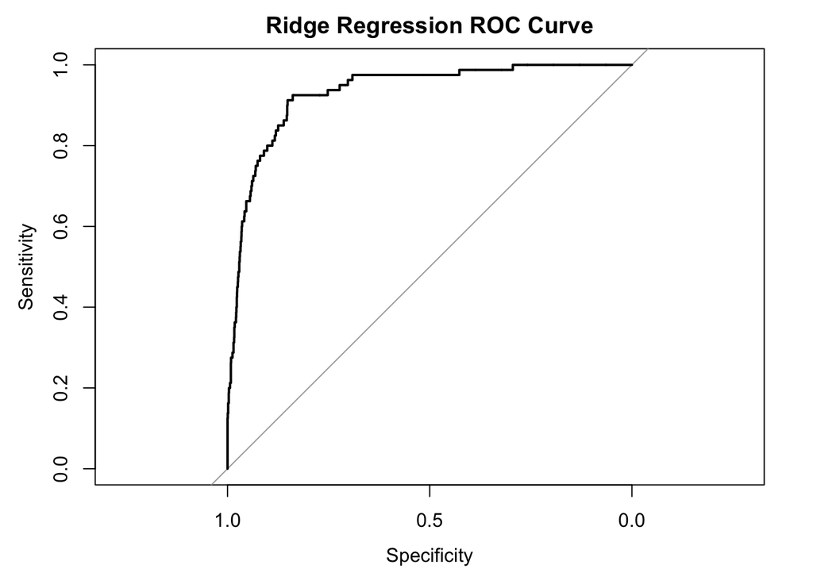

The Ridge Regression model achieved an AUC of .9318, indicating excellent ability to distinguish between bankrupt and non-bankrupt firms. An AUC this high means the model correctly ranks risky companies above healthy ones the vast majority of the time, even across different probability thresholds. This strong discriminative performance is especially noteworthy given the dataset’s extreme class imbalance, demonstrating that Ridge Regression is highly effective at identifying high-risk firms despite the data’s challenging structure.

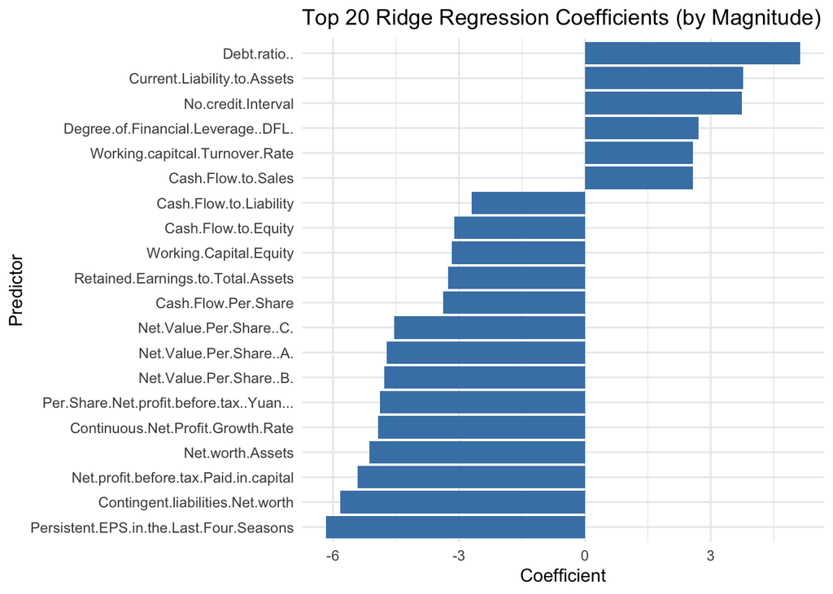

The top 20 Ridge Regression coefficients highlight which financial ratios have the strongest influence on bankruptcy after shrinkage is applied. Variables with large positive coefficients, such as Debt Ratio and Current Liability to Assets, increase the predicted probability of bankruptcy, indicating they are strong risk indicators. In contrast, variables with large negative coefficients, such as Persistent EPS in the Last Four Seasons and Contingent Liabilities to Net Worth, reduce predicted bankruptcy risk. Since Ridge shrinks correlated predictors together rather than eliminating them, this ranking reflects the overall combined importance of financial ratios rather than selecting just a few individual features.

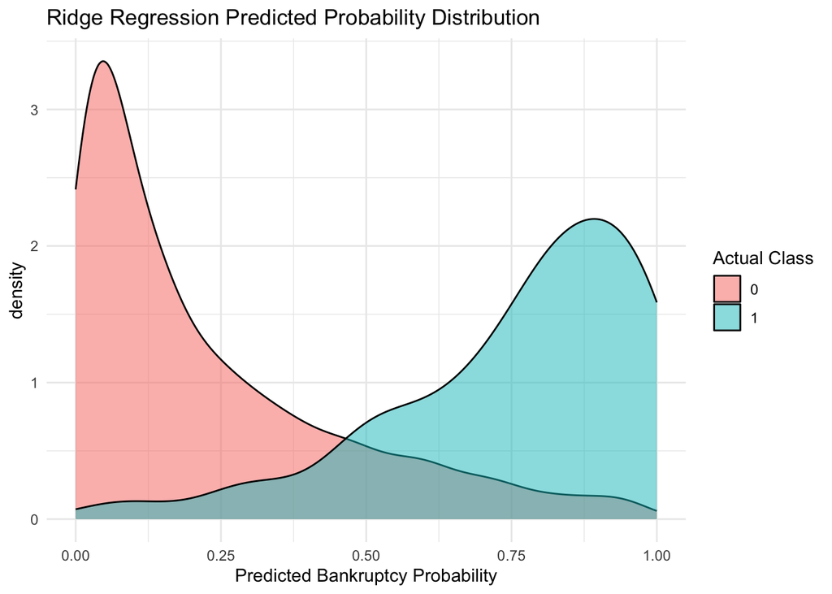

This probability distribution plot shows how well the Ridge Regression model separates bankrupt and non-bankrupt companies based on predicted risk scores. Non-bankrupt firms (Actual Class 0) are mostly concentrated near very low predicted probabilities, while bankrupt firms (Actual Class 1) cluster toward the higher end of the probability scale. Although there is some overlap in the middle range, as expected given the noisy, imbalanced data, the two distributions remain well-separated. This indicates that the model assigns meaningfully different risk levels to the two groups and effectively ranks firms by bankruptcy likelihood.

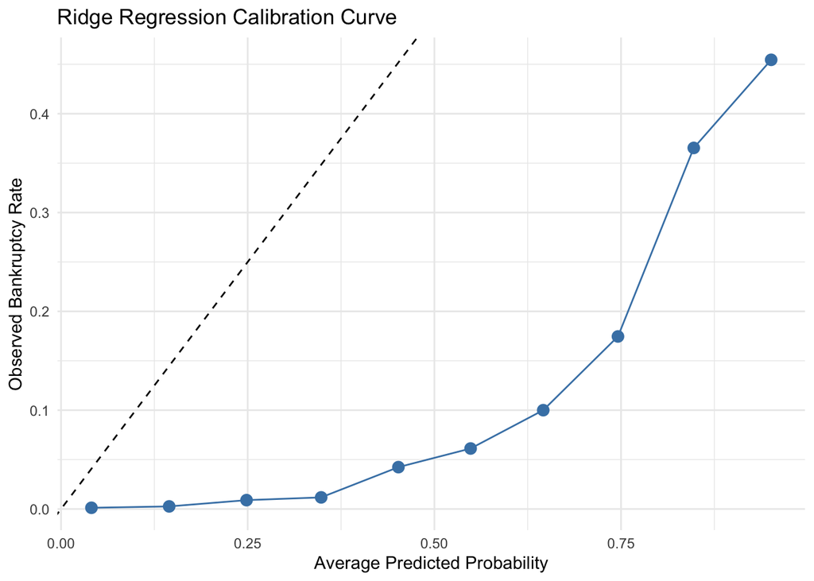

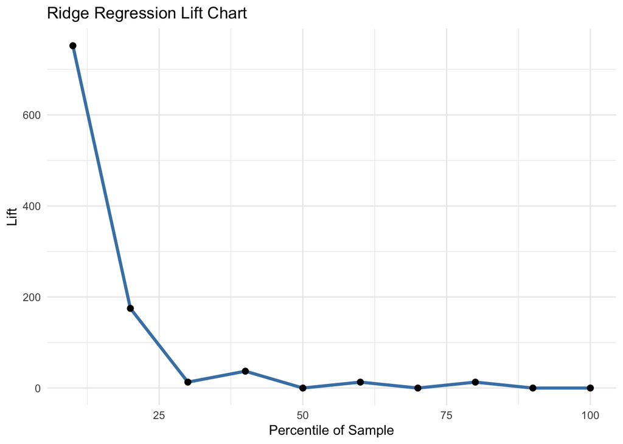

The lift chart shows how effectively Ridge Regression identifies the highest-risk companies. The very first segment of the ranked predictions achieves extremely high lift, meaning the model concentrates a disproportionately large share of actual bankruptcies among the firms it ranks as most likely to fail. Lift drops sharply after this top group, and later segments approach the performance of random selection. This pattern indicates that Ridge is highly effective at prioritizing the riskiest companies, even if its probability calibration is not perfect.

Top 10 Highest-Risk Companies

| Index | Predicted_Prob | Actual |
| --- | --- | --- |
| 554 | 0.9999 | 1 |
| 1988 | 0.9999 | 1 |
| 808 | 0.9995 | 1 |
| 746 | 0.9991 | 1 |
| 1487 | 0.9981 | 1 |
| 516 | 0.9973 | 1 |
| 580 | 0.9947 | 1 |
| 514 | 0.9947 | 1 |
| 1989 | 0.9903 | 1 |
| 699 | 0.9818 | 1 |

The table lists the 10 companies with the highest predicted probability of bankruptcy according to Ridge Regression. All ten firms have extremely high predicted probabilities, and most importantly, every company in this group is actually labeled bankrupt in the test set. This demonstrates that the model is highly effective at identifying the most at-risk firms. When Ridge assigns a near-certain probability of bankruptcy, it is consistently correct. This strong alignment between predicted risk and true outcomes reinforces the model’s value for early-warning screening and prioritizing firms that require immediate attention.

## Results

To evaluate the final model performance, we tested the Ridge Regression model on our test dataset. Ridge was selected because it demonstrated strong discriminative performance, stability under multicollinearity, and effective handling of the highly imbalanced class structure.

Across the test set, Ridge achieved an accuracy of 0.8583, a sensitivity of 0.8625, and a specificity of 0.8581. Below are interpretations of these values in the context of the problem:

- 85.83% of the time, the Ridge Regression model will correctly identify if a company will go bankrupt or not
- 86.25% of the time, the Ridge Regression model will correctly identify a company that will go bankrupt
- 85.81% of the time, the Ridge Regression model will correctly identify a company that will not go bankrupt

Importantly, Ridge produced an AUC of .9318, indicating excellent ability to rank companies by bankruptcy risk. Below is the interpretation of this value in the context of the problem:

- The Ridge Regression model has a 93.18% chance of correctly ranking a randomly chosen bankrupt firm above a randomly chosen non-bankrupt firm

The model consistently assigns very low probabilities to healthy firms and high probabilities to bankrupt firms, as shown in the validation probability distribution plot.

Interpreting the final fitted model, the largest coefficient magnitudes indicate which financial ratios contribute most strongly to bankruptcy risk. Variables such as Debt Ratio, Current Liability to Assets, and No Credit Interval increase the predicted bankruptcy probability, while metrics such as Persistent EPS over the Last Four Seasons and Contingent Liabilities to Net Worth reduce risk. Since Ridge shrinks correlated predictors together, their rankings reflect overall risk signals rather than reliance on a single feature.

Finally, we examined the model’s highest-risk predictions. The top 10 firms with the highest predicted risk in the test set were all labeled as bankrupt, demonstrating that Ridge is highly effective at identifying the most vulnerable companies. This makes the model particularly useful for early warning systems and for prioritizing firms for further financial assessment.

Overall, Ridge Regression provides strong predictive accuracy, excellent ranking performance, and interpretable financial drivers of bankruptcy, making it a reliable model for this application.

## Conclusion

In this analysis, we developed and evaluated several predictive models for bankruptcy classification and ultimately selected Ridge Regression as the final model due to its strong performance, stability under multicollinearity, and reliable handling of highly imbalanced financial data. Ridge achieved high accuracy and an AUC above .93, demonstrating excellent ability to distinguish between bankrupt and non-bankrupt firms, while its coefficient structure provided meaningful insight into the financial ratios most associated with bankruptcy risk. Model validation further showed that Ridge effectively ranks firms by risk and reliably identifies the highest-risk companies. Overall, the Ridge Regression model offers a strong balance of predictive accuracy, interpretability, and robustness, making it well-suited for risk assessment applications.